# SALES ANALYSIS

```python
import numpy as np
import pandas as pd
import matplotlib.pyplot as plt
import seaborn as sns
```

```python
df1 = pd.read_csv(r"C:\Users\Raj's PC\Downloads\Sales_January_2019.csv")
df2 = pd.read_csv(r"C:\Users\Raj's PC\Downloads\Sales_February_2019.csv")
df3 = pd.read_csv(r"C:\Users\Raj's PC\Downloads\Sales_March_2019.csv")
df4 = pd.read_csv(r"C:\Users\Raj's PC\Downloads\Sales_April_2019.csv")
df5 = pd.read_csv(r"C:\Users\Raj's PC\Downloads\Sales_May_2019.csv")
df6 = pd.read_csv(r"C:\Users\Raj's PC\Downloads\Sales_June_2019.csv")
df7 = pd.read_csv(r"C:\Users\Raj's PC\Downloads\Sales_July_2019.csv")
df8 = pd.read_csv(r"C:\Users\Raj's PC\Downloads\Sales_August_2019.csv")
df9 = pd.read_csv(r"C:\Users\Raj's PC\Downloads\Sales_September_2019.csv")
df10 = pd.read_csv(r"C:\Users\Raj's PC\Downloads\Sales_October_2019.csv")
df11 = pd.read_csv(r"C:\Users\Raj's PC\Downloads\Sales_November_2019.csv")
df12 = pd.read_csv(r"C:\Users\Raj's PC\Downloads\Sales_December_2019.csv")
```

```python
df1.shape
```

```
(9723, 6)
```

```python
df = pd.concat([df1,df2,df3,df4,df5,df6,df7,df8,df9,df10,df11,df12])
```

```python
df.iloc[1073]
```

```
Order ID                    Order ID
Product                      Product
Quantity Ordered    Quantity Ordered
Price Each                Price Each
Order Date                Order Date
Purchase Address    Purchase Address
Name: 1073, dtype: object
```

```python
# what was  the best  month  for sales ? how  much was  earned  that  month
```

```python
df.info()
```

```
<class 'pandas.core.frame.DataFrame'>
Index: 186850 entries, 0 to 25116
Data columns (total 6 columns):
 #   Column            Non-Null Count   Dtype
---  ------            --------------   -----
 0   Order ID          186305 non-null  object
 1   Product           186305 non-null  object
 2   Quantity Ordered  186305 non-null  object
 3   Price Each        186305 non-null  object
 4   Order Date        186305 non-null  object
 5   Purchase Address  186305 non-null  object
dtypes: object(6)
memory usage: 10.0+ MB
```

```python
df.isnull().sum()
```

```
Order ID            545
Product             545
Quantity Ordered    545
Price Each          545
Order Date          545
Purchase Address    545
dtype: int64
```

```python
# adding  column of month ,year  , date
df['Month'] = df['Order Date'].str.split('/').str[0]
```

```python
df.drop('Month' ,axis = 1 , inplace = True)
df.head()
```

|  | Order ID | Product | Quantity Ordered | Price Each | Order Date | Purchase Address |
| --- | --- | --- | --- | --- | --- | --- |
| 0 | 141234 | iPhone | 1 | 700 | 01/22/19 21:25 | 944 Walnut St, Boston, MA 02215 |
| 1 | 141235 | Lightning Charging Cable | 1 | 14.95 | 01/28/19 14:15 | 185 Maple St, Portland, OR 97035 |
| 2 | 141236 | Wired Headphones | 2 | 11.99 | 01/17/19 13:33 | 538 Adams St, San Francisco, CA 94016 |
| 3 | 141237 | 27in FHD Monitor | 1 | 149.99 | 01/05/19 20:33 | 738 10th St, Los Angeles, CA 90001 |
| 4 | 141238 | Wired Headphones | 1 | 11.99 | 01/25/19 11:59 | 387 10th St, Austin, TX 73301 |

```python
# there  are some data which is  null we have to remove that data  from the dataset
df = df[~df['Month'].isnull()]
```

```python
df.shape
```

```
(186305, 7)
```

##### now here there will no null values in the data

##### we have drop the null values because all the columns were null total 545 rows among all the 545rows there were no values in that row

now we can convert the datatype of the month from object to integer dtype

```python
df.head()
```

|  | Order ID | Product | Quantity Ordered | Price Each | Order Date | Purchase Address | Month |
| --- | --- | --- | --- | --- | --- | --- | --- |
| 0 | 141234 | iPhone | 1 | 700 | 01/22/19 21:25 | 944 Walnut St, Boston, MA 02215 | 01 |
| 1 | 141235 | Lightning Charging Cable | 1 | 14.95 | 01/28/19 14:15 | 185 Maple St, Portland, OR 97035 | 01 |
| 2 | 141236 | Wired Headphones | 2 | 11.99 | 01/17/19 13:33 | 538 Adams St, San Francisco, CA 94016 | 01 |
| 3 | 141237 | 27in FHD Monitor | 1 | 149.99 | 01/05/19 20:33 | 738 10th St, Los Angeles, CA 90001 | 01 |
| 4 | 141238 | Wired Headphones | 1 | 11.99 | 01/25/19 11:59 | 387 10th St, Austin, TX 73301 | 01 |

```python
pd.to_numeric(df['Quantity Ordered'])
```

```python
# adding sales columns
df['Quantity Ordered'] * df['Price Each']
```

```python
df['Quantity Ordered'].iloc[1069]
```

```
'Quantity Ordered'
```

```python
as we can see here that here is the error in the dataset  its should be drop
df[df['Quantity Ordered'].str.contains('Quantity Ordered')]
```

|  | Order ID | Product | Quantity Ordered | Price Each | Order Date | Purchase Address | Month |
| --- | --- | --- | --- | --- | --- | --- | --- |
| 1073 | Order ID | Product | Quantity Ordered | Price Each | Order Date | Purchase Address | Order Date |
| 1102 | Order ID | Product | Quantity Ordered | Price Each | Order Date | Purchase Address | Order Date |
| 1194 | Order ID | Product | Quantity Ordered | Price Each | Order Date | Purchase Address | Order Date |
| 1897 | Order ID | Product | Quantity Ordered | Price Each | Order Date | Purchase Address | Order Date |
| 2463 | Order ID | Product | Quantity Ordered | Price Each | Order Date | Purchase Address | Order Date |
| ... | ... | ... | ... | ... | ... | ... | ... |
| 23198 | Order ID | Product | Quantity Ordered | Price Each | Order Date | Purchase Address | Order Date |
| 23337 | Order ID | Product | Quantity Ordered | Price Each | Order Date | Purchase Address | Order Date |
| 23748 | Order ID | Product | Quantity Ordered | Price Each | Order Date | Purchase Address | Order Date |
| 24192 | Order ID | Product | Quantity Ordered | Price Each | Order Date | Purchase Address | Order Date |
| 24222 | Order ID | Product | Quantity Ordered | Price Each | Order Date | Purchase Address | Order Date |

355 rows × 7 columns

```python
df
```

|  | Order ID | Product | Quantity Ordered | Price Each | Order Date | Purchase Address | Month |
| --- | --- | --- | --- | --- | --- | --- | --- |
| 0 | 141234 | iPhone | 1 | 700 | 01/22/19 21:25 | 944 Walnut St, Boston, MA 02215 | 01 |
| 1 | 141235 | Lightning Charging Cable | 1 | 14.95 | 01/28/19 14:15 | 185 Maple St, Portland, OR 97035 | 01 |
| 2 | 141236 | Wired Headphones | 2 | 11.99 | 01/17/19 13:33 | 538 Adams St, San Francisco, CA 94016 | 01 |
| 3 | 141237 | 27in FHD Monitor | 1 | 149.99 | 01/05/19 20:33 | 738 10th St, Los Angeles, CA 90001 | 01 |
| 4 | 141238 | Wired Headphones | 1 | 11.99 | 01/25/19 11:59 | 387 10th St, Austin, TX 73301 | 01 |
| ... | ... | ... | ... | ... | ... | ... | ... |
| 25112 | 319666 | Lightning Charging Cable | 1 | 14.95 | 12/11/19 20:58 | 14 Madison St, San Francisco, CA 94016 | 12 |
| 25113 | 319667 | AA Batteries (4-pack) | 2 | 3.84 | 12/01/19 12:01 | 549 Willow St, Los Angeles, CA 90001 | 12 |
| 25114 | 319668 | Vareebadd Phone | 1 | 400 | 12/09/19 06:43 | 273 Wilson St, Seattle, WA 98101 | 12 |
| 25115 | 319669 | Wired Headphones | 1 | 11.99 | 12/03/19 10:39 | 778 River St, Dallas, TX 75001 | 12 |
| 25116 | 319670 | Bose SoundSport Headphones | 1 | 99.99 | 12/21/19 21:45 | 747 Chestnut St, Los Angeles, CA 90001 | 12 |

186305 rows × 7 columns

```python
# as we here we are getting the error  we are not able to convert the  datatype of this  columns so we will drop this kind of  data in the data set
# there are total 355  rows  of this  kind  its not giving any fruitfull information
df[df['Quantity Ordered'] == 'Quantity Ordered']
```

|  | Order ID | Product | Quantity Ordered | Price Each | Order Date | Purchase Address | Month |
| --- | --- | --- | --- | --- | --- | --- | --- |
| 1073 | Order ID | Product | Quantity Ordered | Price Each | Order Date | Purchase Address | Order Date |
| 1102 | Order ID | Product | Quantity Ordered | Price Each | Order Date | Purchase Address | Order Date |
| 1194 | Order ID | Product | Quantity Ordered | Price Each | Order Date | Purchase Address | Order Date |
| 1897 | Order ID | Product | Quantity Ordered | Price Each | Order Date | Purchase Address | Order Date |
| 2463 | Order ID | Product | Quantity Ordered | Price Each | Order Date | Purchase Address | Order Date |
| ... | ... | ... | ... | ... | ... | ... | ... |
| 23198 | Order ID | Product | Quantity Ordered | Price Each | Order Date | Purchase Address | Order Date |
| 23337 | Order ID | Product | Quantity Ordered | Price Each | Order Date | Purchase Address | Order Date |
| 23748 | Order ID | Product | Quantity Ordered | Price Each | Order Date | Purchase Address | Order Date |
| 24192 | Order ID | Product | Quantity Ordered | Price Each | Order Date | Purchase Address | Order Date |
| 24222 | Order ID | Product | Quantity Ordered | Price Each | Order Date | Purchase Address | Order Date |

355 rows × 7 columns

```python
df = df[df['Quantity Ordered'] != 'Quantity Ordered']
```

```python
# previous  shape  of the data was  this  before droping the 355 rows
df.shape
```

```
(186305, 7)
```

```python
# after  dropping the   355 rows  of the data in dataset
df.shape
```

```
(185950, 7)
```

```python
df.drop('Month',axis = 1 , inplace = True)
```

```python
df.head()
```

|  | Order ID | Product | Quantity Ordered | Price Each | Order Date | Purchase Address |
| --- | --- | --- | --- | --- | --- | --- |
| 0 | 141234 | iPhone | 1 | 700 | 01/22/19 21:25 | 944 Walnut St, Boston, MA 02215 |
| 1 | 141235 | Lightning Charging Cable | 1 | 14.95 | 01/28/19 14:15 | 185 Maple St, Portland, OR 97035 |
| 2 | 141236 | Wired Headphones | 2 | 11.99 | 01/17/19 13:33 | 538 Adams St, San Francisco, CA 94016 |
| 3 | 141237 | 27in FHD Monitor | 1 | 149.99 | 01/05/19 20:33 | 738 10th St, Los Angeles, CA 90001 |
| 4 | 141238 | Wired Headphones | 1 | 11.99 | 01/25/19 11:59 | 387 10th St, Austin, TX 73301 |

```python
df['Order_Month'] = df['Order Date'].str.split('/').str[0]
```

```python
df.head()
```

|  | Order ID | Product | Quantity Ordered | Price Each | Order Date | Purchase Address | Order_Month |
| --- | --- | --- | --- | --- | --- | --- | --- |
| 0 | 141234 | iPhone | 1 | 700 | 01/22/19 21:25 | 944 Walnut St, Boston, MA 02215 | 01 |
| 1 | 141235 | Lightning Charging Cable | 1 | 14.95 | 01/28/19 14:15 | 185 Maple St, Portland, OR 97035 | 01 |
| 2 | 141236 | Wired Headphones | 2 | 11.99 | 01/17/19 13:33 | 538 Adams St, San Francisco, CA 94016 | 01 |
| 3 | 141237 | 27in FHD Monitor | 1 | 149.99 | 01/05/19 20:33 | 738 10th St, Los Angeles, CA 90001 | 01 |
| 4 | 141238 | Wired Headphones | 1 | 11.99 | 01/25/19 11:59 | 387 10th St, Austin, TX 73301 | 01 |

```python
df['Order_date'] = df['Order Date'].str.split('/').str[1]
```

```python
df['Order_year'] = df['Order Date'].str.split('/').str[2].str.split(' ').str[0]
```

```python
df['Order_time'] = df['Order Date'].str.split('/').str[2].str.split(' ').str[1]
```

```python
df.head()
```

|  | Order ID | Product | Quantity Ordered | Price Each | Order Date | Purchase Address | Order_Month | Order_date | Order_year | Order_time |
| --- | --- | --- | --- | --- | --- | --- | --- | --- | --- | --- |
| 0 | 141234 | iPhone | 1 | 700 | 01/22/19 21:25 | 944 Walnut St, Boston, MA 02215 | 01 | 22 | 19 | 21:25 |
| 1 | 141235 | Lightning Charging Cable | 1 | 14.95 | 01/28/19 14:15 | 185 Maple St, Portland, OR 97035 | 01 | 28 | 19 | 14:15 |
| 2 | 141236 | Wired Headphones | 2 | 11.99 | 01/17/19 13:33 | 538 Adams St, San Francisco, CA 94016 | 01 | 17 | 19 | 13:33 |
| 3 | 141237 | 27in FHD Monitor | 1 | 149.99 | 01/05/19 20:33 | 738 10th St, Los Angeles, CA 90001 | 01 | 05 | 19 | 20:33 |
| 4 | 141238 | Wired Headphones | 1 | 11.99 | 01/25/19 11:59 | 387 10th St, Austin, TX 73301 | 01 | 25 | 19 | 11:59 |

```python
df.drop('Order Date' ,axis = 1 , inplace = True)
```

```python
df.head()
```

|  | Order ID | Product | Quantity Ordered | Price Each | Purchase Address | Order_Month | Order_date | Order_year | Order_time |
| --- | --- | --- | --- | --- | --- | --- | --- | --- | --- |
| 0 | 141234 | iPhone | 1 | 700 | 944 Walnut St, Boston, MA 02215 | 01 | 22 | 19 | 21:25 |
| 1 | 141235 | Lightning Charging Cable | 1 | 14.95 | 185 Maple St, Portland, OR 97035 | 01 | 28 | 19 | 14:15 |
| 2 | 141236 | Wired Headphones | 2 | 11.99 | 538 Adams St, San Francisco, CA 94016 | 01 | 17 | 19 | 13:33 |
| 3 | 141237 | 27in FHD Monitor | 1 | 149.99 | 738 10th St, Los Angeles, CA 90001 | 01 | 05 | 19 | 20:33 |
| 4 | 141238 | Wired Headphones | 1 | 11.99 | 387 10th St, Austin, TX 73301 | 01 | 25 | 19 | 11:59 |

```python
# now we will convert the object  dtype  to int
df['Quantity Ordered'] = df['Quantity Ordered'].astype(int)
```

```python
# now we will convert the object  dtype  to int
df['Price Each'] = df['Price Each'].astype(float)
```

```python
# nwo  we can take the sales  column by producting  the  quantity Ordered and price  each  column
df['Sales'] = df['Quantity Ordered'] * df['Price Each']
```

```python
df.head()
```

|  | Order ID | Product | Quantity Ordered | Price Each | Purchase Address | Order_Month | Order_date | Order_year | Order_time | Sales |
| --- | --- | --- | --- | --- | --- | --- | --- | --- | --- | --- |
| 0 | 141234 | iPhone | 1 | 700.00 | 944 Walnut St, Boston, MA 02215 | 01 | 22 | 19 | 21:25 | 700.00 |
| 1 | 141235 | Lightning Charging Cable | 1 | 14.95 | 185 Maple St, Portland, OR 97035 | 01 | 28 | 19 | 14:15 | 14.95 |
| 2 | 141236 | Wired Headphones | 2 | 11.99 | 538 Adams St, San Francisco, CA 94016 | 01 | 17 | 19 | 13:33 | 23.98 |
| 3 | 141237 | 27in FHD Monitor | 1 | 149.99 | 738 10th St, Los Angeles, CA 90001 | 01 | 05 | 19 | 20:33 | 149.99 |
| 4 | 141238 | Wired Headphones | 1 | 11.99 | 387 10th St, Austin, TX 73301 | 01 | 25 | 19 | 11:59 | 11.99 |

```python
# what was the best month for sales ? how  much was  earned that month?
df.groupby('Order_Month')['Sales'].sum().sort_values(ascending = False).head(1)
```

```
Order_Month
12    4613443.34
Name: Sales, dtype: float64
```

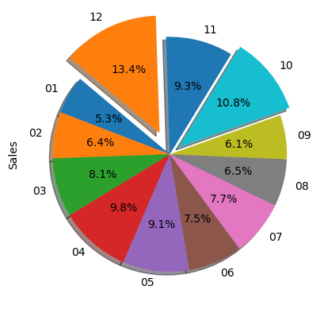

```python
temp_df = df.groupby('Order_Month')['Sales'].sum().plot(kind = 'pie' , autopct = '%0.1f%%' ,shadow = True , explode = [0,0,0,0,0,0,0,0,0,0.1,0,0.2,] ,startangle = 140)
```

```python
temp_df
```

```python
temp_df = df.groupby('Order_Month')['Sales'].sum()
```

```python
temp_df = temp_df.reset_index()
```

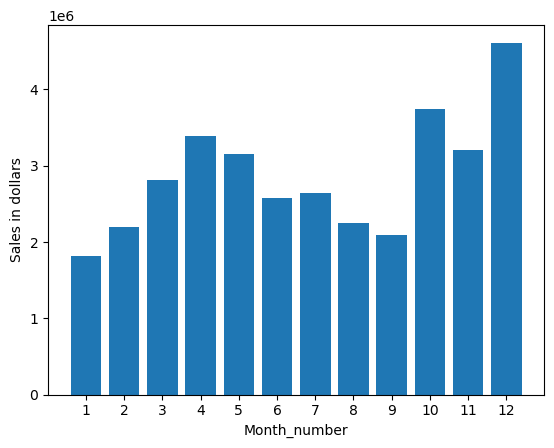

```python
month = range(1,13)

plt.bar(month , temp_df['Sales'])
plt.xticks(month)
plt.xlabel('Month_number')
plt.ylabel('Sales in dollars')
plt.show()
```

```python
# what usa city have higher  numeber of sales
df.head()
# for this question we have to split up the purchase address  because in puchase address their is a city located  lets  see how  we  are going to do that
```

|  | Order ID | Product | Quantity Ordered | Price Each | Purchase Address | Order_Month | Order_date | Order_year | Order_time | Sales |
| --- | --- | --- | --- | --- | --- | --- | --- | --- | --- | --- |
| 0 | 141234 | iPhone | 1 | 700.00 | 944 Walnut St, Boston, MA 02215 | 01 | 22 | 19 | 21:25 | 700.00 |
| 1 | 141235 | Lightning Charging Cable | 1 | 14.95 | 185 Maple St, Portland, OR 97035 | 01 | 28 | 19 | 14:15 | 14.95 |
| 2 | 141236 | Wired Headphones | 2 | 11.99 | 538 Adams St, San Francisco, CA 94016 | 01 | 17 | 19 | 13:33 | 23.98 |
| 3 | 141237 | 27in FHD Monitor | 1 | 149.99 | 738 10th St, Los Angeles, CA 90001 | 01 | 05 | 19 | 20:33 | 149.99 |
| 4 | 141238 | Wired Headphones | 1 | 11.99 | 387 10th St, Austin, TX 73301 | 01 | 25 | 19 | 11:59 | 11.99 |

from above method we can also use this different method like making a function def get_city(x): return x.split(',').str[1] df['city'] = df['Purchase Address'].apply(lambda x: get_city(x)) df.head()

```python
# in Purchase Addres  the null values is 0
df['city'] = df['Purchase Address'].str.split(',').str[1]
```

```python
df.head()
```

|  | Order ID | Product | Quantity Ordered | Price Each | Purchase Address | Order_Month | Order_date | Order_year | Order_time | Sales | city |
| --- | --- | --- | --- | --- | --- | --- | --- | --- | --- | --- | --- |
| 0 | 141234 | iPhone | 1 | 700.00 | 944 Walnut St, Boston, MA 02215 | 01 | 22 | 19 | 21:25 | 700.00 | Boston |
| 1 | 141235 | Lightning Charging Cable | 1 | 14.95 | 185 Maple St, Portland, OR 97035 | 01 | 28 | 19 | 14:15 | 14.95 | Portland |
| 2 | 141236 | Wired Headphones | 2 | 11.99 | 538 Adams St, San Francisco, CA 94016 | 01 | 17 | 19 | 13:33 | 23.98 | San Francisco |
| 3 | 141237 | 27in FHD Monitor | 1 | 149.99 | 738 10th St, Los Angeles, CA 90001 | 01 | 05 | 19 | 20:33 | 149.99 | Los Angeles |
| 4 | 141238 | Wired Headphones | 1 | 11.99 | 387 10th St, Austin, TX 73301 | 01 | 25 | 19 | 11:59 | 11.99 | Austin |

```python
# so now going  with  the question
# what usa city have higher  numeber of sales
temp_citySales = df.groupby('city')['Sales'].sum().reset_index()
```

```python
temp_citySales
```

|  | city | Sales |
| --- | --- | --- |
| 0 | Atlanta | 2795498.58 |
| 1 | Austin | 1819581.75 |
| 2 | Boston | 3661642.01 |
| 3 | Dallas | 2767975.40 |
| 4 | Los Angeles | 5452570.80 |
| 5 | New York City | 4664317.43 |
| 6 | Portland | 2320490.61 |
| 7 | San Francisco | 8262203.91 |
| 8 | Seattle | 2747755.48 |

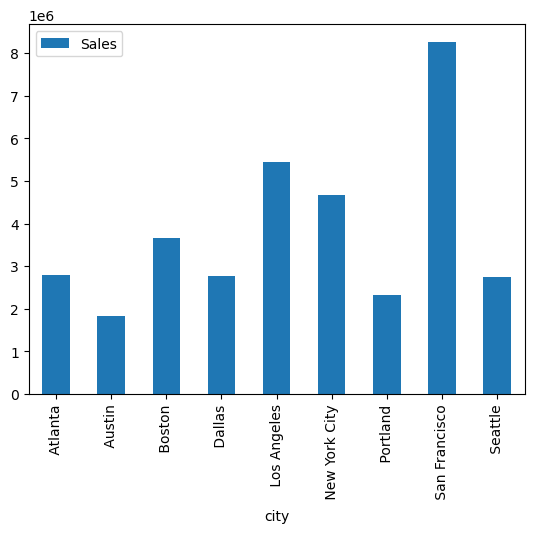

```python
city = temp_citySales['city']
temp_citySales.plot(kind = 'bar' ,x = 'city' )
```

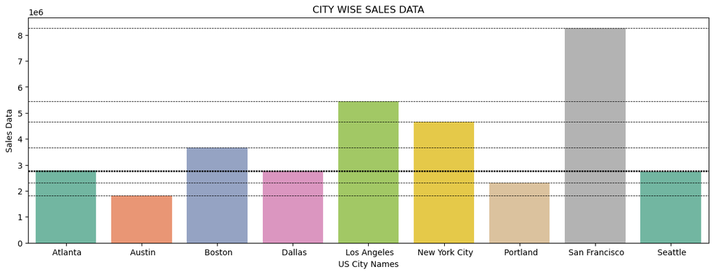

```python
plt.figure(figsize = (15,5))
plt.tight_layout()
sns.barplot(data  = temp_citySales , x = 'city' , y = 'Sales' , palette = 'Set2')
for i in range(temp_citySales.shape[0]):
    plt.axhline(temp_citySales['Sales'].values[i] , color = 'k' , linestyle = '--' , linewidth = 0.6)
plt.title('CITY WISE SALES DATA')
plt.xlabel('US City Names')
plt.ylabel('Sales Data')
plt.show()
```

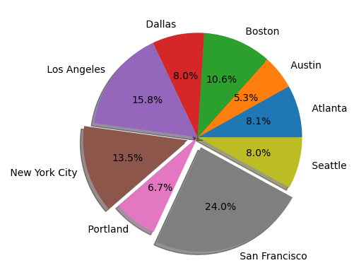

```python
plt.pie(x = temp_citySales['Sales'] , labels = temp_citySales['city'] , labeldistance = 1.1,shadow = True ,autopct = '%0.1f%%' , explode = [0,0,0,0,0,0.1,0,0.1,0])
plt.show()
```

here SanFrancisco has most most number of the sales city wise

```python
# what time should we display advertisements to  maximise likehood of customer's buying products ?
# for this  question we have to extract  hour from  the order time column which we will going to see  next
df['Order_time']
```

[output not shown]

```python
df['Hour'] = df['Order_time'].str.split(':').str[0]
```

```python
df.head()
```

|  | Order ID | Product | Quantity Ordered | Price Each | Purchase Address | Order_Month | Order_date | Order_year | Order_time | Sales | city | Hour |
| --- | --- | --- | --- | --- | --- | --- | --- | --- | --- | --- | --- | --- |
| 0 | 141234 | iPhone | 1 | 700.00 | 944 Walnut St, Boston, MA 02215 | 01 | 22 | 19 | 21:25 | 700.00 | Boston | 21 |
| 1 | 141235 | Lightning Charging Cable | 1 | 14.95 | 185 Maple St, Portland, OR 97035 | 01 | 28 | 19 | 14:15 | 14.95 | Portland | 14 |
| 2 | 141236 | Wired Headphones | 2 | 11.99 | 538 Adams St, San Francisco, CA 94016 | 01 | 17 | 19 | 13:33 | 23.98 | San Francisco | 13 |
| 3 | 141237 | 27in FHD Monitor | 1 | 149.99 | 738 10th St, Los Angeles, CA 90001 | 01 | 05 | 19 | 20:33 | 149.99 | Los Angeles | 20 |
| 4 | 141238 | Wired Headphones | 1 | 11.99 | 387 10th St, Austin, TX 73301 | 01 | 25 | 19 | 11:59 | 11.99 | Austin | 11 |

```python
temp_hour_sales = df.groupby('Hour')['Sales'].sum().sort_values(ascending = False).reset_index()
temp_hour_sales.head(3)
```

|  | Hour | Sales |
| --- | --- | --- |
| 0 | 19 | 2412938.54 |
| 1 | 12 | 2316821.34 |
| 2 | 11 | 2300610.24 |

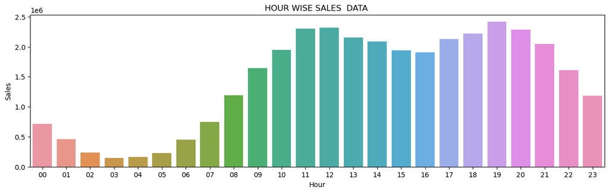

```python
plt.figure(figsize = (15,4))
sns.barplot(data = temp_hour_sales ,x = 'Hour',y = 'Sales')
plt.title('HOUR WISE SALES  DATA ')
plt.show()
```

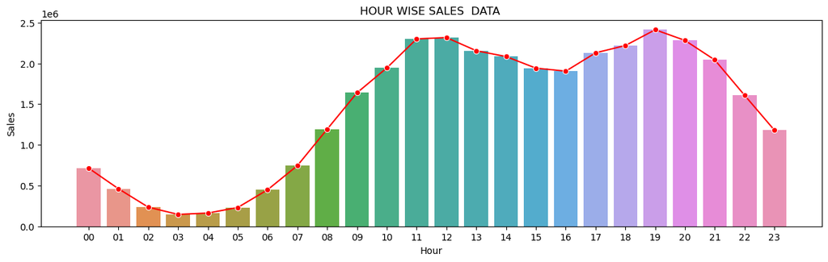

```python
plt.figure(figsize = (15,4))
sns.barplot(data = temp_hour_sales ,x = 'Hour',y = 'Sales')
sns.lineplot(data=temp_hour_sales, x='Hour', y='Sales', color='r', marker='o')
plt.title('HOUR WISE SALES  DATA ')
plt.show()
```

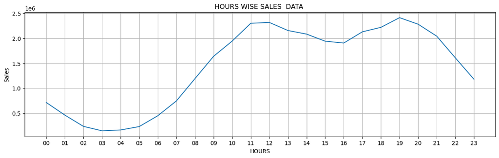

```python
plt.figure(figsize = (15,4))
sns.lineplot(data = temp_hour_sales ,x = 'Hour',y = 'Sales')
plt.title('HOURS WISE SALES  DATA ')
plt.xlabel('HOURS')
plt.grid()
plt.show()
# same recommendation from the above   bar graph
```

```python
# what month should we display advertisements to  maximise likehood of customer's buying products ?
temp_month_sales = df.groupby('Order_Month')['Sales'].sum().reset_index()
```

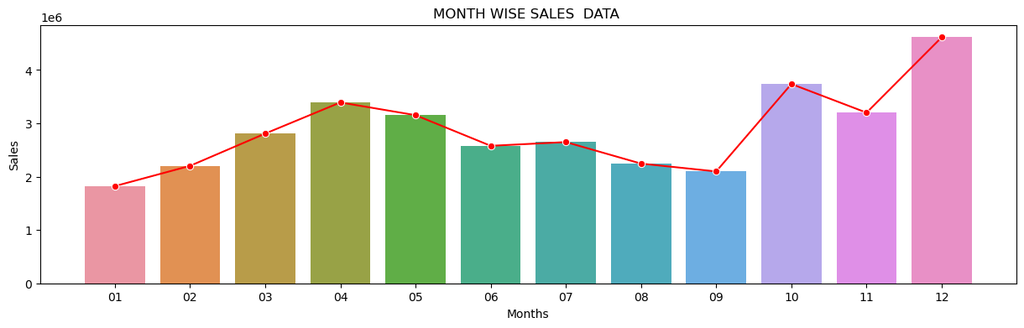

```python
plt.figure(figsize = (15,4))
sns.barplot(data = temp_month_sales ,x = 'Order_Month',y = 'Sales')
sns.lineplot(data=temp_month_sales, x='Order_Month', y='Sales', color='r', marker='o')
plt.title('MONTH WISE SALES  DATA ')
plt.xlabel('Months')
plt.show()
```

##### Recommendation is that BEST MONTH for advertisement from above graph is around OCTOBER AND DECEMBER MORE ON DECEMBER

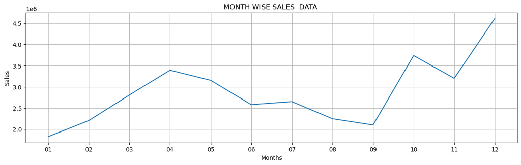

```python
plt.figure(figsize = (15,4))
sns.lineplot(data = temp_month_sales ,x = 'Order_Month',y = 'Sales')
plt.title('MONTH WISE SALES  DATA ')
plt.xlabel('Months')
plt.grid()
plt.show()
```

#### FROM LINE CHART WE CAN SEE THAT WE SHOULD DO ADVERTISEMENT BETWEEN (JANUARY TO APRIL) THEN (SEPTEMBER TO OCTOBER) THEN (NOVEMBER TO DECEMBER) BECAUSE AT THAT TIME THE SALES ARE INCREASING

```python
df.head()
```

```python
temp_duplicates = df[df['Order ID'].duplicated(keep = False)]
```

```python
# now we will add the column which will have products of  same  order__id
temp_duplicates.groupby(['Order ID','Product']).size()
```

```python
temp_duplicates['Same_products_order_id'] = temp_duplicates.groupby('Order ID')['Product'].transform(lambda x: ','.join(x))
```

```python
df.head()
```

|  | Order ID | Product | Quantity Ordered | Price Each | Purchase Address | Order_Month | Order_date | Order_year | Order_time | Sales | city | Hour |
| --- | --- | --- | --- | --- | --- | --- | --- | --- | --- | --- | --- | --- |
| 0 | 141234 | iPhone | 1 | 700.00 | 944 Walnut St, Boston, MA 02215 | 01 | 22 | 19 | 21:25 | 700.00 | Boston | 21 |
| 1 | 141235 | Lightning Charging Cable | 1 | 14.95 | 185 Maple St, Portland, OR 97035 | 01 | 28 | 19 | 14:15 | 14.95 | Portland | 14 |
| 2 | 141236 | Wired Headphones | 2 | 11.99 | 538 Adams St, San Francisco, CA 94016 | 01 | 17 | 19 | 13:33 | 23.98 | San Francisco | 13 |
| 3 | 141237 | 27in FHD Monitor | 1 | 149.99 | 738 10th St, Los Angeles, CA 90001 | 01 | 05 | 19 | 20:33 | 149.99 | Los Angeles | 20 |
| 4 | 141238 | Wired Headphones | 1 | 11.99 | 387 10th St, Austin, TX 73301 | 01 | 25 | 19 | 11:59 | 11.99 | Austin | 11 |

```python
temp = df.groupby(['Product'])['Sales'].sum().sort_values(ascending = False).reset_index()
```

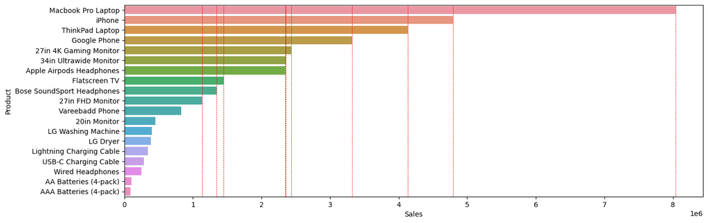

```python
# what are the product with sales
plt.figure(figsize =(15,5))
sns.barplot(data = temp , y = 'Product' , x = 'Sales' , orient = "h")
for i in range(temp['Sales'].shape[0]):
    if temp['Sales'].values[i] > 1000000:
        plt.axvline(temp['Sales'].values[i] , color = 'r' , linestyle = '--' , linewidth = 0.6)
```

### so here we can see that macbookpro is has the most number of sales

```python
temp1 = df.groupby(['Order_Month','Product'])['Sales'].sum().sort_values(ascending = False).reset_index().set_index('Order_Month').nlargest(12,'Sales',keep = 'first')
temp1
```

```python
plt.figure(figsize= (15,5))
sns.scatterplot(data = temp1 , x ='Order_Month',y = 'Sales',size = 'Sales' ,palette = 'Set2')
```

[output not shown]

#### Q : what product sold the most ? why we think it sold the most

```python
df.head()
```

|  | Order ID | Product | Quantity Ordered | Price Each | Purchase Address | Order_Month | Order_date | Order_year | Order_time | Sales | city | Hour |
| --- | --- | --- | --- | --- | --- | --- | --- | --- | --- | --- | --- | --- |
| 0 | 141234 | iPhone | 1 | 700.00 | 944 Walnut St, Boston, MA 02215 | 01 | 22 | 19 | 21:25 | 700.00 | Boston | 21 |
| 1 | 141235 | Lightning Charging Cable | 1 | 14.95 | 185 Maple St, Portland, OR 97035 | 01 | 28 | 19 | 14:15 | 14.95 | Portland | 14 |
| 2 | 141236 | Wired Headphones | 2 | 11.99 | 538 Adams St, San Francisco, CA 94016 | 01 | 17 | 19 | 13:33 | 23.98 | San Francisco | 13 |
| 3 | 141237 | 27in FHD Monitor | 1 | 149.99 | 738 10th St, Los Angeles, CA 90001 | 01 | 05 | 19 | 20:33 | 149.99 | Los Angeles | 20 |
| 4 | 141238 | Wired Headphones | 1 | 11.99 | 387 10th St, Austin, TX 73301 | 01 | 25 | 19 | 11:59 | 11.99 | Austin | 11 |

```python
temp_product_quantity_order = df.groupby('Product')['Quantity Ordered'].count().reset_index()
```

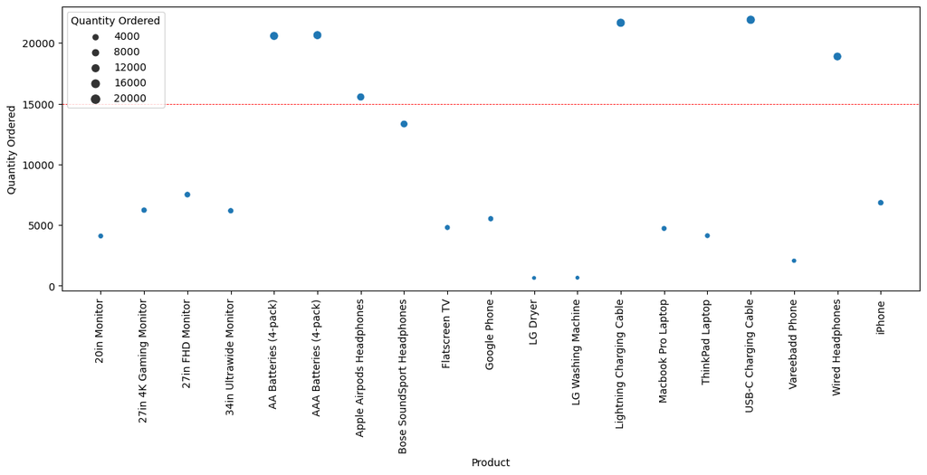

```python
plt.figure(figsize = (15,5))
sns.scatterplot(data = temp_product_quantity_order ,x = temp_product_quantity_order['Product'] , y = temp_product_quantity_order['Quantity Ordered'] , size = temp_product_quantity_order['Quantity Ordered'])
plt.xticks(rotation = 90)
plt.axhline(15000 , color = 'r' , linestyle = '--' , linewidth = 0.6)
plt.show()
```

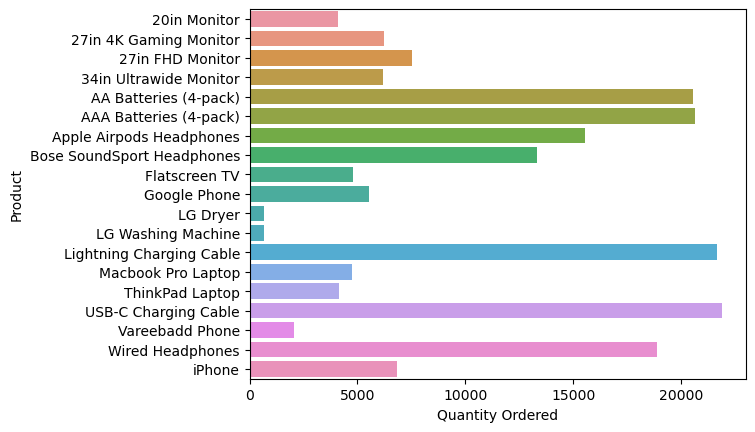

```python
sns.barplot(data = temp_product_quantity_order ,y  = 'Product' , x = 'Quantity Ordered' , orient = "h")
```

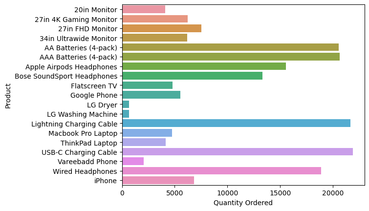

```python
sns.barplot(data = temp_product_quantity_order ,y  = 'Product' , x = 'Quantity Ordered' , orient = "h")
```

```python
h = temp_product_quantity_order.sort_values(by = 'Quantity Ordered', ascending = True)
```

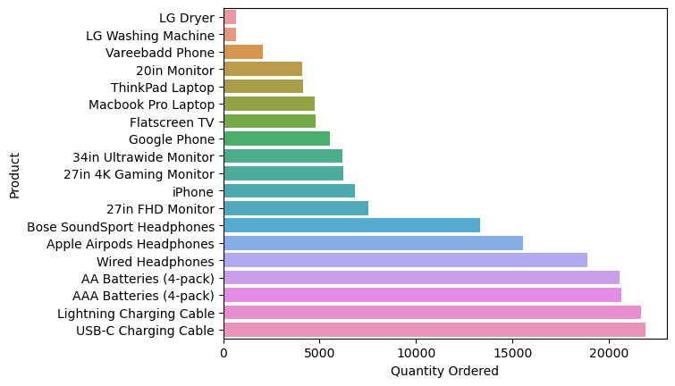

```python
sns.barplot(data = h ,y  = 'Product' , x = 'Quantity Ordered' , orient = "h")
```

### as we can see here the we if compare the [roducts with sales then we see that MACBOOK PRO LAPTOP is mostly selled but if we compare that same product with the QUANTITY ORDERED then we can see that USB-C CHARGING CABLE ordered more than 20000 and MACBOOK PRO LAPTOP ordered around 5000

### here they have higher ordering rate because they are cheap than other products compared to their rate

#### so here revenue is more generted by the sales of macbook pro laptop rather than usb-c charging cable

```python
df[df['Product'] == 'USB-C Charging Cable'] # 11.95
```

```python
df.groupby('Product')['Price Each'].mean()
fig , ax1 = plt.subplots()

ax2 = ax1.twinx()
ax1.bar(products , quntity )
```

[output not shown]

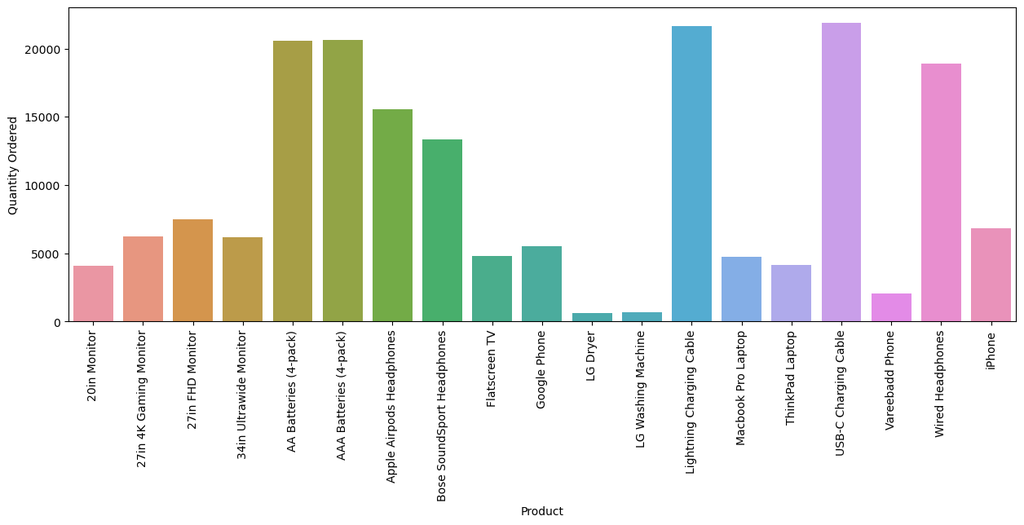

```python
plt.figure(figsize = (15,5))
sns.barplot(data = temp_product_quantity_order ,x  = 'Product' , y = 'Quantity Ordered')
plt.xticks(rotation = 90)
plt.show()
# this graph is for max value of  the products
```

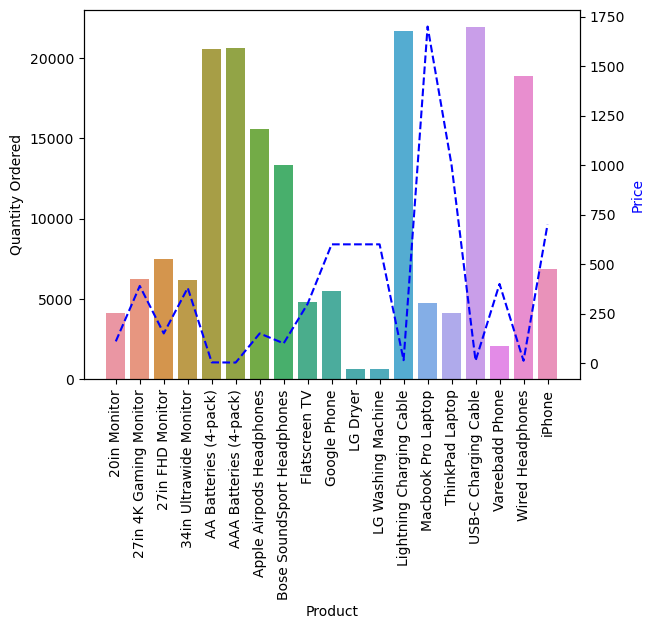

```python
plt.figure(figsize = (15,5))
fig ,ax1 = plt.subplots()
sns.barplot(data = temp_product_quantity_order ,x  = 'Product' , y = 'Quantity Ordered')
plt.xticks(rotation = 90)
ax2 = ax1.twinx()
ax2.plot(product , prices , 'b--' , )
ax2.set_ylabel('Price' , color = 'b')
plt.show()
```

#### as we can see here that if the quantity order is high then price will be low so here Quantity ordered and price are inversely propotioanl